# Reproducible Research: Peer Assessment 1

## Loading and preprocessing the data

In order to begin analyzing, we must first unzip the archive in the repository.

```r
unzip("activity.zip")
```

### Reading the data

We load the data into memory, and display the first 10 rows to see what it looks like.

```r
data <- read.csv("activity.csv")
head(data, 10)
```

```
##    steps       date interval
## 1     NA 2012-10-01        0
## 2     NA 2012-10-01        5
## 3     NA 2012-10-01       10
## 4     NA 2012-10-01       15
## 5     NA 2012-10-01       20
## 6     NA 2012-10-01       25
## 7     NA 2012-10-01       30
## 8     NA 2012-10-01       35
## 9     NA 2012-10-01       40
## 10    NA 2012-10-01       45
```

We may want to create a separate POSIX date column, which makes it easier to work with dates.

```r
data$posix_date <- strptime(paste(data$date, data$interval), "%Y-%m-%d %M")
```

## What is mean total number of steps taken per day?

### Per Diem Totals

We calculate the total number of steps taken per day. To simplify things, we ignore NA values.

```r
perdiem <- tapply(data$steps, data$date, sum)
```

The following bar graph shows the total number of steps taken each day for the duration of the study. The reason we chose a bar graph is because it did not make sense to use a histogram to compare the total number of steps taken each day.

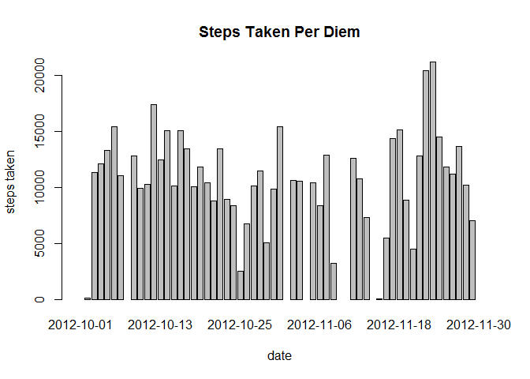

```r
barplot(perdiem, main = "Steps Taken Per Diem", xlab = "date", ylab = "steps taken")
```

### Distribution of Steps Taken

Here is a histogram showing the distribution of steps with the frequency measured in **no. of days**.

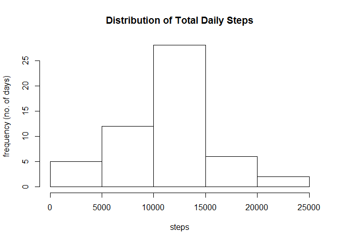

```r
hist(perdiem, main = "Distribution of Total Daily Steps", xlab = "steps", ylab = "frequency (no. of days)")
```

### Mean and Median Totals

In order to obtain the mean and median **total** number of steps taken per day, we do the following:

```r
avg_perdiem <- mean(perdiem, na.rm = TRUE)
med_perdiem <- median(perdiem, na.rm = TRUE)
```

The mean of the total number of steps taken per day is: 10766.188679 and the median is: 10765.000000.

## What is the average daily activity pattern?

I think that what is meant here by “averaging across all days” is to take the *per diem* average of the steps completed during each 5-minute interval for that day. Here is the code and plot for this. Note that there are missing values. In the y-axis, we denote the expected value of steps per interval as **E[steps per interval]**.

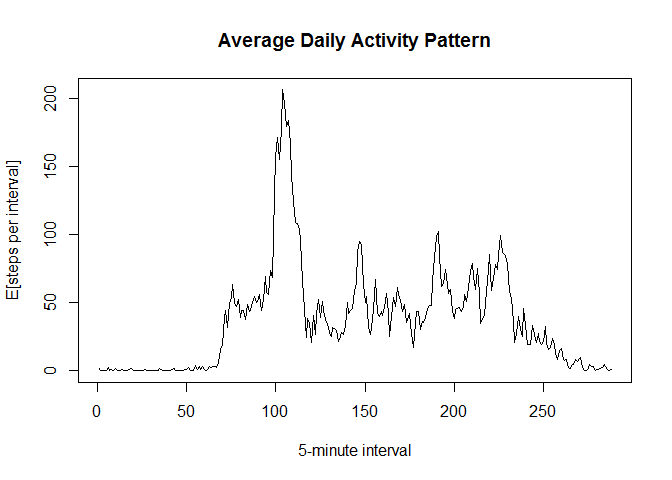

```r
avint <- tapply(data$steps, data$interval, mean, na.rm = TRUE)
plot(avint,
     main = "Average Daily Activity Pattern",
     xlab = "5-minute interval",
     ylab = "E[steps per interval]",
     type = "l")
```

1. Find the date with the highest expected value of steps per 5-minute interval.

```r
avint <- tapply(data$steps, data$date, mean, na.rm = TRUE) # need the total steps per day
mx <- max(avint[!is.nan(avint)]) # maximum expected value across all the days
date <- names(avint[!is.nan(avint) & avint == mx])
```

2. Pull the interval with the highest number of steps for that day.

```r
subset1 <- !is.na(data$steps)
subset2 <- data$date == date
subset3 <- data$steps == max(data$steps[data$date == date])

mxint <- data$interval[subset1 & subset2 & subset3]
```

And, the 5-minute interval containing the maximum number of steps on the day with the highest average number of steps per interval (2012-11-23) is: 1525. In this case, we interpolated between two max values that were found on the same day, namely: 1520 and 1530.

## Imputing missing values

```r
dat2 <- data # deep copy, I hope... kidding, I did check!
dat2$steps[is.na(dat2$steps)] <- mean(dat2$steps, na.rm = TRUE)
```

### Imputation Analysis

Now let us do something similar to what we did before, to calculate the per diem number of steps, make the chart, and report the **mean** and **median** total number of steps taken per day.

We let **pr2diem** be the total number of steps taken per day, and use **barplot** to obtain a chart.

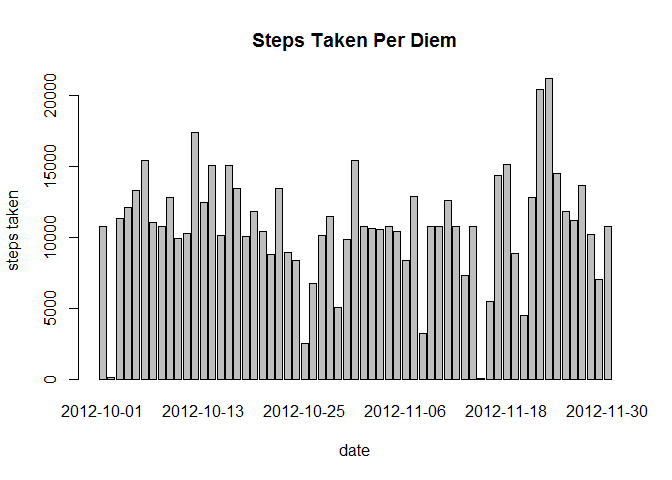

```r
pr2diem <- tapply(dat2$steps, dat2$date, sum, na.rm = TRUE)
barplot(pr2diem, main = "Steps Taken Per Diem", xlab = "date", ylab = "steps taken")
```

And now, we calculate the mean and median **total** number of steps, as we did before.

```r
avg_pr2diem <- mean(pr2diem, na.rm = TRUE)
med_pr2diem <- median(pr2diem, na.rm = TRUE)
```

The mean of the total number of steps taken per day is: 10766.188679 and the median is: 10766.188679.

#### Taking a Closer Look at Mean and Median

I do not understand how the mean and median turned out to be the equal after imputing the missing data, but let us take a look at the distribution. We would expect a Gaussian distrubtion if the mean and median are, indeed, the same.

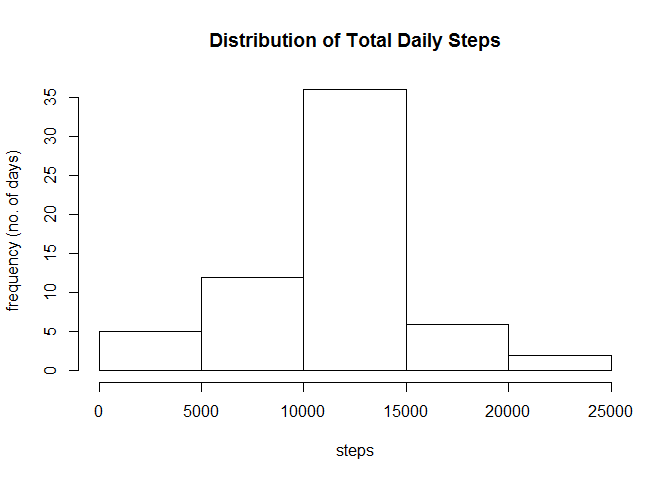

```r
hist(pr2diem, main = "Distribution of Total Daily Steps", xlab = "steps", ylab = "frequency (no. of days)")
```

#### Analyzing the Impact of Missing-Data Imputation

- The absolute difference for mean is: 0.
- The absolute difference for median is: 1.1886792.

Now, let us see what changes there are in the activity patterns by filling in the missing values.

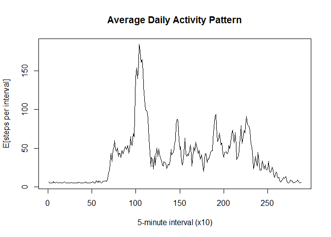

```r
plot(tapply(dat2$steps, dat2$interval, mean, na.rm = TRUE),
            main = "Average Daily Activity Pattern",
            xlab = "5-minute interval (x10)",
            ylab = "E[steps per interval]",
            type = "l")
```

### An Alternative Approach to Imputation

Okay, the last approach seemed to have done something about the missing values. I am still concerned about the way missing values were treated. I did find imputation techniques and R packages online, such as Amelia. I will not use Amelia in the current study, but will consider for the future. I will try to generate more “realistic” values by generating random numbers up to one standard deviation above the mean, and fill in that way.

```r
dat3 <- data # deep copy!
dat3_sd = sd(dat3$steps, na.rm = TRUE)
dat3_mean = mean(dat3$steps, na.rm = TRUE)

set.seed(0) # need to set the seed to make this experiment reproducible
len <- length(dat3$steps[is.na(dat3$steps)])
dat3$steps[is.na(dat3$steps)] <- (dat3_mean + dat3_sd) * runif(len) # yes, we are evading for loops again
```

### Imputation Analysis II

Did it work? Let us try to get the absolute difference again, as follows:

First we let *pr3diem* be the total number of steps taken per day.

```r
pr3diem <- tapply(dat3$steps, dat3$date, sum, na.rm = TRUE)
```

We calculate the mean and median **total** number of steps, as we did before.

```r
avg_pr3diem <- mean(pr3diem, na.rm = TRUE)
med_pr3diem <- median(pr3diem, na.rm = TRUE)
```

The mean and median differences using this second technique are as follows:

- The absolute difference for the mean is: 1364.2691213.
- The absolute difference for the median is: 693.

#### Summary

I do not know how accurate my technique is, but let us see what the activity patterns looks like this time:

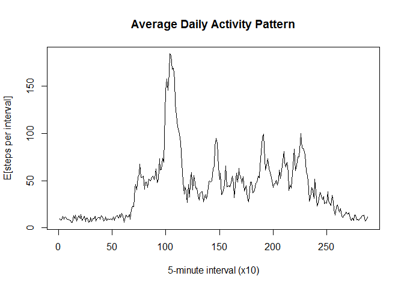

```r
plot(tapply(dat3$steps, dat3$interval, mean, na.rm = TRUE),
            main = "Average Daily Activity Pattern",
            xlab = "5-minute interval (x10)",
            ylab = "E[steps per interval]",
            type = "l")
```

Finally, we will take a look at the distribution of steps using our alternative missing-data imputation technique, to see how much “randomness” we introduced (hoping that it was realistic randomness).

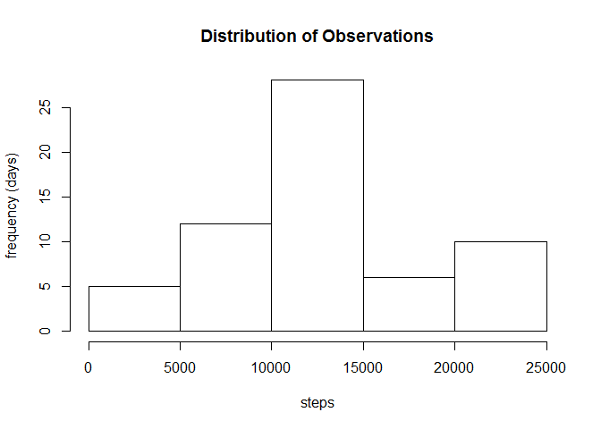

```r
hist(pr3diem, main = "Distribution of Observations", xlab = "steps", ylab = "frequency (days)")
```

In sum, using mean and standard deviation with a random multiple between 0 and 1 does not yield a distribution of steps that approximates the original distribution of data with missing values (the original distribution having a positive skewness). Why is missing-data imputation so challenging?

## Are there differences in activity patterns between weekdays and weekends?

Here are the activity patterns for weekdays vs. weekends.

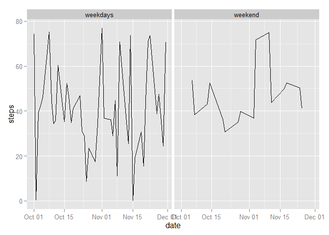

```r
library(ggplot2)

dat3$weekdays <- weekdays(as.Date(dat3$date))
dat3$isweekend <- dat3$weekdays %in% c("Saturday", "Sunday")

daily_activity <- tapply(dat3$steps, dat3$date, mean)
date = as.Date(names(daily_activity))
steps = daily_activity

dat4 <- data.frame(date, steps)
dat4$weekdays <- weekdays(date)
dat4$isweekend <- dat4$weekdays %in% c("Saturday", "Sunday")
dat4$isweekend <- factor(dat4$isweekend, labels = c("weekdays", "weekend"))

qplot(date, steps, data = dat4, facets = . ~ isweekend, geom = "line")
```